# 08_draft_report

# Part 2: Our code

**The models we used (same as theirs):**

- base model reg0 is $y = \beta_0 + \beta_1y_{t-1} + \beta_2y_{t-12}$
- Trend model reg1 is $y = \beta_0 + \beta_1y_{t-1} + \beta_2y_{t-12} + \beta_3suvs + \beta_4insurance$

**The out of sample forcasting method we used:**

- Moving window forecast: Starting from the 18th month in the data, we use only the previous 17 months (1.5 years), instead of all the previous months, to train a model and predict the next month.
- function to use in oosf.R: OutOfSampleForecast0112_mw()

## 2.1 Create function for model and evaluation using our new out of sample forecast functions

```r
getEvaluation_0112mv <- function(data, plot_title = "log(sales) over time"){
  zooObj <- zoo(data[,-1], as.Date(data[,1]))
  y <- log(zooObj$sales)
  x <- zooObj[, c("suvs", "insurance")]
  z <- OutOfSampleForecast0112_mw(y,x,17)
  MaeReport(z, plot_title = plot_title)
}
```

## 2.2 Our code, paper’s data

```r
attach(mtcars)
par(mfrow=c(2,1))
getEvaluation_0112mv(dat, plot_title = "our code paper data") # recall dat is the data in merged.csv
```

```
## [1] "our code paper data MAE"
```

```
##   mae.base mae.trends  mae.delta
## 0.06154527 0.05531033 0.10130653
```

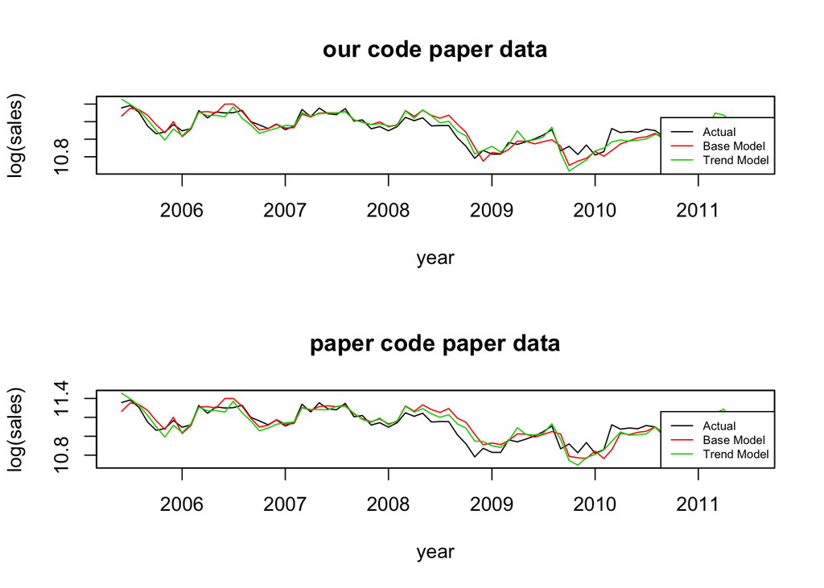

```
## [1] "paper code paper data MAE"
##   mae.base mae.trends  mae.delta
## 0.06343984 0.05667658 0.10660890
```

```r
#compare MAE from rolling window
getModelandEvaluation(dat, print=0, plot_title = "paper code paper data") #default print = 1 prints model summary
```

**2.2 Observations:**

- We see that the MAE values are similar to the paper’s, off by 0.5%. Note that the base model was also trained using moving window.